# Lab 3: The Normal Distribution

October 4, 2018

SETUP: What is your birthday? Replace “0” with your birthday below. For example, my birthday is April 2nd, so I will put “402”.

```r
set.seed(402)
```

## The Dataset

This analysis is an exploration of a dataset containing the results of ALL college basketball games in the 2015-2016 season. (Not just Cal Poly’s games!). The data has been loaded and named `bball`.

```r
bball %>% head()
```

```
## # A tibble: 6 x 8
##       X Date  Team  Team.Location Team.Score Opponent Opponent.Score
##   <int> <fct> <fct> <fct>              <int> <fct>             <int>
## 1     1 11/1~ Old ~ Neutral               67 Niagara              50
## 2     2 11/1~ Niag~ Neutral               50 Old Dom~             67
## 3     3 11/1~ Sacr~ Neutral               76 Quinnip~             64
## 4     4 11/1~ Quin~ Neutral               64 Sacred ~             76
## 5     5 11/1~ Texas Neutral               71 Washing~             77
## 6     6 11/1~ Wrig~ Neutral               77 South D~             69
## # ... with 1 more variable: Team.Result <fct>
```

```r
bball %>% summary()
```

```
##        X               Date                       Team
##  Min.   :    1   11/13/15: 310   Akron              :   35
##  1st Qu.: 2914   2/6/16  : 306   Austin Peay        :   35
##  Median : 5827   1/9/16  : 300   Bowling Green State:   35
##  Mean   : 5827   1/16/16 : 288   Buffalo            :   35
##  3rd Qu.: 8740   1/30/16 : 286   Fresno State       :   35
##  Max.   :11653   2/13/16 : 286   Green Bay          :   35
##                  (Other) :9877   (Other)            :11443
##  Team.Location    Team.Score                    Opponent
##  Away   :5240   Min.   : 25.00   Akron              :   35
##  Home   :5251   1st Qu.: 64.00   Austin Peay        :   35
##  Neutral:1162   Median : 72.00   Bowling Green State:   35
##                 Mean   : 72.54   Buffalo            :   35
##                 3rd Qu.: 81.00   Fresno State       :   35
##                 Max.   :144.00   Green Bay          :   35
##                                  (Other)            :11443
##  Opponent.Score   Team.Result
##  Min.   : 25.00   Loss:5821
##  1st Qu.: 64.00   Win :5832
##  Median : 72.00
##  Mean   : 72.51
##  3rd Qu.: 81.00
##  Max.   :144.00
##
```

[This is an observational dataset of all college basketball games. It includes the teams that played, their scores, and whether the game was home or away for the first team listed.]

## Checking Normality

Use the code chunk below to make a histogram of the variable `Team.Score`. Include an estimated density in this plot. (Hint: Refer back to the “Histograms” section of the Quantitative Variables lab exercise.)

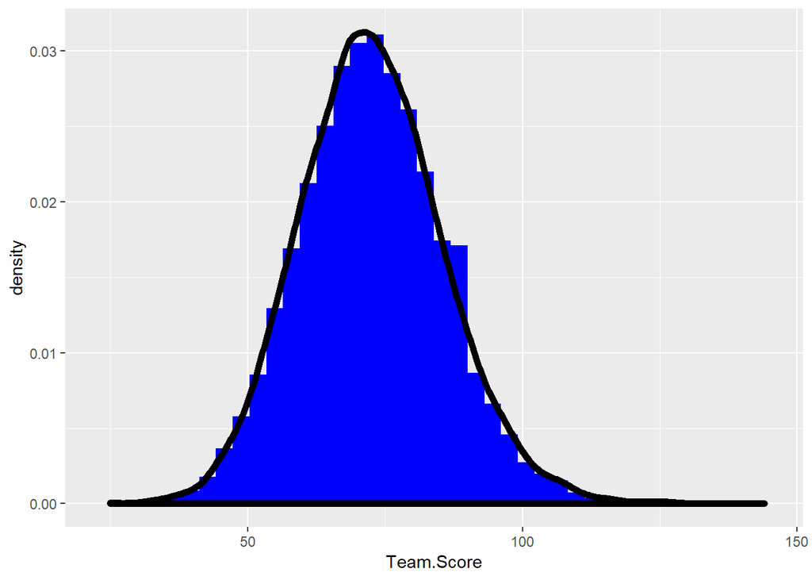

```r
ggplot(bball, aes(x = Team.Score)) + geom_histogram(fill = "blue", bins = 40, aes(y = ..density..)) + geom_density(size = 2)
```

Do you think the random variable “Number of points scored by a college basketball team” is Normal? Why or why not?

[Yep, the histogram looks like a bell curve!]